# Causal ML: Partially linear Double ML

Simulation notebook

Michael Knaus

02/23

Goals:

- Hand-code partially linear Double ML

# Data generating process

Consider the following DGP:

This means that we are in a highly nonlinear setting, but only one variable ($X_1$) is relevant and the others are just noise. We draw a sample of $N=100$ and inspect it.

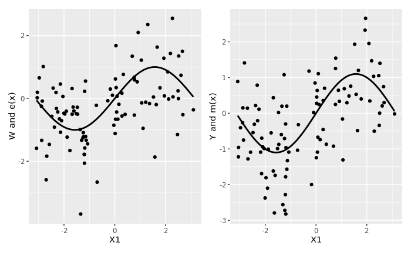

```r
# To install the causalDML package uncomment the following two lines
# library(devtools)
# install_github(repo="MCKnaus/causalDML")

library(hdm)
library(grf)
library(causalDML)
library(tidyverse)
library(patchwork)

set.seed(1234)

n = 100
p = 10

theta = 0.1

x = matrix(runif(n*p,-pi,pi),ncol=p)
e = function(x){sin(x)}
m = function(x){theta*e(x) + sin(x)}
w = e(x[,1]) + rnorm(n,0,1)
y = theta*w + sin(x[,1]) + rnorm(n,0,1)

df = data.frame(x=x[,1],w,y)
g1 = ggplot(df,aes(x=x, y=w)) + stat_function(fun=e,linewidth=1) + ylab("W and e(x)") + geom_point() + xlab("X1")
g2 = ggplot(df,aes(x=x, y=y)) + stat_function(fun=m,linewidth=1) + ylab("Y and m(x)") + geom_point() + xlab("X1")
g1 | g2
```

# Hand-coded residual-on-residual regression w/o cross-fitting

We estimate the nuisance parameters $e(X)=E[W|X]$ and $m(X)=E[Y|X]$ using random forest without honesty (sample size too small for honesty) and use the respective residuals in a residual-on-residual regression (RORR) w/o constant:

```r
# No cross-fitting
rf = regression_forest(x,w,honesty=F)
ehat = predict(rf,newdata=x)$predictions
# Predict outcome in-sample
rf = regression_forest(x,y,honesty=F)
mhat = predict(rf,newdata=x)$predictions
# Get residuals
res_y = y-mhat
res_w = w-ehat
# Run residual-on-residual regression (RORR)
lm_robust(res_y ~ 0+res_w)$coefficients
```

```
    res_w
0.1528582
```

Note that the ultimate hand-coded version uses the equation of the slides, which gives the equivalent estimate
$$\hat{\theta} = \frac{\frac{1}{N}\sum_{i=1}^N (Y_i
- \hat{m}(X_i)) (W_i - \hat{e}(X_i))}{\frac{1}{N}\sum_{i=1}^N (W_i -
\hat{e}(X_i))^2}$$

```r
cat("Fully hand-coded:\n",mean(res_y * res_w) / mean(res_w^2))
```

```
Fully hand-coded:
 0.1528582
```

# Hand-coded residual-on-residual regression with 2-fold cross-fitting

The theoretical results require that we predict the nuisance parameters out-of-sample. The easiest way to do this is via two-fold cross-fitting:

- Split the sample in two random subsamples, S1 and S2
- Form prediction models in S1, use it to predict in S2
- Form prediction models in S2, use it to predict in S1
- Run RORR with the combined predictions

```r
# Initialize nuisance vectors
mhat = ehat = rep(NA,n)
# Draw random indices for sample 1
index_s1 = sample(1:n,n/2)
# Create S1
x1 = x[index_s1,]
w1 = w[index_s1]
y1 = y[index_s1]
# Create sample 2 with those not in S1
x2 = x[-index_s1,]
w2 = w[-index_s1]
y2 = y[-index_s1]
# Model in S1, predict in S2
rf = regression_forest(x1,w1,honesty=F)
ehat[-index_s1] = predict(rf,newdata=x2)$predictions
rf = regression_forest(x1,y1,honesty=F)
mhat[-index_s1] = predict(rf,newdata=x2)$predictions
# Model in S2, predict in S1
rf = regression_forest(x2,w2,honesty=F)
ehat[index_s1] = predict(rf,newdata=x1)$predictions
rf = regression_forest(x2,y2,honesty=F)
mhat[index_s1] = predict(rf,newdata=x1)$predictions
# RORR
res_y = y-mhat
res_w = w-ehat
lm(res_y ~ 0+res_w)$coefficients
```

```
    res_w
0.1715412
```

# Residual-on-residual regression with 5-fold cross-fitting

2-fold cross-fitting is easy to implement but especially in small sample sizes, using only 50% of the data to estimate the nuisance parameters might lead to unstable predictions.

Thus, we use the `DML_partial_linear` function of the `causalDML` package to run 5-fold cross-fitting. This package requires to create the methods that we use because it allows for ensemble methods. For now, we focus again on the plain random forest.

With 5-fold cross-fitting, we split the sample in 5 folds and use 4 folds (80% of the data) to predict the left out fold (20% of the data). We iterate such that every fold is left out once.

```r
# 5-fold cross-fitting with causalDML package
# Create learner
forest = create_method("forest_grf",args=list(honesty=F))
# Run partially linear model
pl_cf5 = DML_partial_linear(y,w,x,ml_w=list(forest),ml_y=list(forest),cf=5)
summary(pl_cf5)
```

```
     Coefficient       SE      t   p
[1,]    0.099296 0.095309 1.0418 0.3
```

5-fold cross-fitting comes closest with this seed, but this could all be by chance.

# Simulation study

We run a simulation study drawing $M=100$ samples from the DGP described above and estimate the effect with eight different estimators:

- Double Selection with only the 10 main variables
- Double Selection with the 10 main variables and their squared values
- Double Selection including up to the third order polynomial of the main variables
- Double Selection including up to the fourth order polynomial of the main variables
- Double Selection including up to the fifth order polynomial of the main variables
- Partially linear model estimated w/o cross-fitting
- Partially linear model estimated with 2-fold cross-fitting
- Partially linear model estimated with 5-fold cross-fitting

```r
# set number of replications
n_rep = 100
# Initialize results matrix
results = matrix(NA,n_rep,8)
colnames(results) = c("DS1","DS2","DS3","DS4","DS5","PL no cf","PL cf2","PL cf5")
# run the simulation
for (i in 1:n_rep) {
  x = matrix(runif(n*p,-pi,pi),ncol=p)
  w = e(x[,1]) + rnorm(n,0,1)
  y = theta*w + sin(x[,1]) + rnorm(n,0,1)

  # double selections
  results[i,1] = rlassoEffect(x,y,w)$alpha
  x2 = cbind(x,x^2)
  results[i,2] = rlassoEffect(x2,y,w)$alpha
  x3 = cbind(x2,x^3)
  results[i,3] = rlassoEffect(x3,y,w)$alpha
  x4 = cbind(x3,x^4)
  results[i,4] = rlassoEffect(x4,y,w)$alpha
  x5 = cbind(x4,x^5)
  results[i,5] = rlassoEffect(x5,y,w)$alpha


  # No cross-fitting
  rf = regression_forest(x,w,honesty=F)
  ehat = predict(rf,newdata=x)$predictions
  rf = regression_forest(x,y,honesty=F)
  mhat = predict(rf,newdata=x)$predictions
  res_y = y-mhat
  res_w = w-ehat
  results[i,6] = lm(res_y ~ 0+res_w)$coefficients

  # 2-fold cross-fitting
  mhat = ehat = rep(NA,n)
  index_s1 = sample(1:n,n/2)
  x1 = x[index_s1,]
  w1 = w[index_s1]
  y1 = y[index_s1]
  x2 = x[-index_s1,]
  w2 = w[-index_s1]
  y2 = y[-index_s1]
  rf = regression_forest(x1,w1,honesty=F)
  ehat[-index_s1] = predict(rf,newdata=x2)$predictions
  rf = regression_forest(x1,y1,honesty=F)
  mhat[-index_s1] = predict(rf,newdata=x2)$predictions
  rf = regression_forest(x2,w2,honesty=F)
  ehat[index_s1] = predict(rf,newdata=x1)$predictions
  rf = regression_forest(x2,y2,honesty=F)
  mhat[index_s1] = predict(rf,newdata=x1)$predictions
  res_y = y-mhat
  res_w = w-ehat
  results[i,7] = lm(res_y ~ 0+res_w)$coefficients

  # 5-fold cross-fitting
  results[i,8] = DML_partial_linear(y,w,x,ml_w=list(forest),ml_y=list(forest),cf=5)$result[1]
}
```

We plot the histograms of Double Selection with fifth order polynomials (those with lower order look very similar), and the three partially linear estimators.

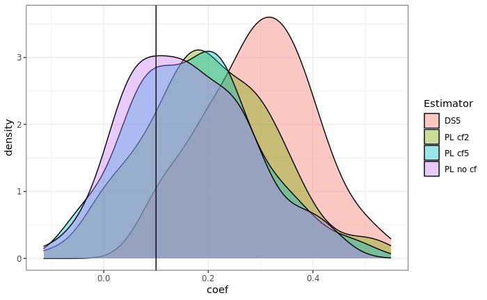

```r
as.data.frame(results[,c(5,6,7,8)]) %>% pivot_longer(cols=everything(),names_to = "Estimator",values_to = "coef") %>%
  ggplot(aes(x = coef, fill = Estimator)) + geom_density(alpha=0.4) + theme_bw() + geom_vline(xintercept=theta)
```

The Double Selection estimator is clearly biased. Those based on the partially linear model also a little bit, but they are remarkably close given that we use only 100 observations.

Lets have a closer look at the performance and check the MSE of the estimators and its decomposition, where $\hat{\theta}_m$ is the estimated parameter in the $m$-th replication:

$$MSE(\hat{\theta)} = M^{-1} \sum_m
(\hat{\theta}_m - \theta)^2 = \underbrace{(\overbrace{M^{-1} \sum_m
\hat{\theta}_m}^{\bar{\theta}} - \theta)^2}_{Bias^2} +
\underbrace{M^{-1} \sum_m (\hat{\theta}_m - \bar{\theta})^2}_{Variance}$$

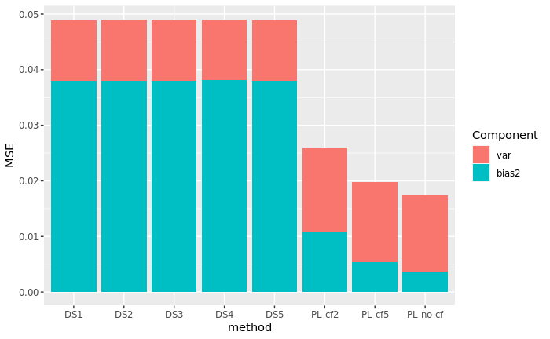

```r
data.frame(method = colnames(results),
           bias2 = colMeans(results-theta)^2,
           var = colMeans(sweep(results,2,colMeans(results))^2)) %>%
  pivot_longer(-method,names_to = "Component",values_to = "MSE") %>%
  ggplot(aes(fill=factor(Component,levels=c("var","bias2")), y=MSE, x=method)) +
  geom_bar(position="stack", stat="identity") + scale_fill_discrete(name = "Component")
```

The worse performance of 2-fold cross-fitting should disappear with larger sample sizes.

In this setting cross-fitting seems not to be required. However, the next notebooks will look closer into this issue and show that it is especially important to get valid inference.

## Take-away

- We can program a cross-fit Double ML partially linear estimator in less than 20 lines of code.
- Double Selection can fail in non-linear DGPs, even if provided with a lot of polynomials.
- In small samples, we should use more than two folds to exploit more information in forming the prediction models.

## Suggestions to play with the toy model

Feel free to play around with the code. This is useful to sharpen and challenge your understanding of the methods. Think about the consequences of a modification before you run it and check whether the results are in line with your expectation. Some suggestions:

- Modify DGP (increase theta, correlation of covariates, coefficients, noise term, …)
- Increase the number of observations
- Increase cross-fitting folds to 10 and/or 20